# Proyecto Final (Wine Data).

## Análisis Estadístico de Datos

### Universidad del Rosario - Escuela de Ingeniería, Ciencia y Tecnología.

#### Robert Daniel Fonseca, Juan Sebastián Alvarado Ramos y Luceth Caterine Argote Radillo.

## Librerías.

```r
if (!require("tidyverse")) install.packages("tidyverse")
if (!require("psych")) install.packages("psych")
if (!require("GGally")) install.packages("GGally")
if (!require("RColorBrewer")) install.packages("RColorBrewer")
if (!require("gmodels")) install.packages("gmodels")
if (!require("readr")) install.packages("readr")
if (!require("corrplot")) install.packages("corrplot")
if (!require("ggpubr")) install.packages("ggpubr")
if (!require("dplyr")) install.packages("dplyr")
if (!require("stats")) install.packages("stats")
if (!require("aplpack")) install.packages("aplpack")
if (!require('factoextra')) install.packages('factoextra')
if (!require('reshape2')) install.packages('reshape2')
if (!require('FactoMineR')) install.packages('FactoMineR')
if (!require('MVN')) install.packages('MVN')
if (!require('mvnormtest')) install.packages('mvnormtest')
if (!require('rstatix')) install.packages('rstatix')
if (!require('forecast')) install.packages('forecast')
if (!require('caret')) install.packages('caret')
if (!require('dendextend')) install.packages('dendextend')
if (!require('fpc')) install.packages('fpc')
if (!require('cluster')) install.packages('cluster')
```

## Datasets.

Se unificaron los datasets en uno solo y se cambiaron los nombres de las columnas:

```r
wine_red <- wine_red %>%
  mutate(type = "red")

wine_white <- wine_white %>%
  mutate(type = "white")

wine <- bind_rows(wine_red, wine_white)

wine <- wine %>%
  rename(fixed_acidity = 'fixed acidity',
         volatile_acidity = 'volatile acidity',
         citric_acid = 'citric acid',
         residual_sugar = 'residual sugar',
         free_sulfur_dioxide = 'free sulfur dioxide',
         total_sulfur_dioxide = 'total sulfur dioxide')
```

Se seleccionaron las variables numéricas:

```r
red_wine_num <- dplyr::select(wine_red, -quality, -type)
white_wine_num <- dplyr::select(wine_white, -quality, -type)
wine_num <- dplyr::select(wine, -quality, -type)
```

## Análisis Descriptivo.

```r
describe(wine_num)
```

|  | vars | n | mean | sd | median | trimmed | mad | min | max | range | skew | kurtosis | se |
| --- | --- | --- | --- | --- | --- | --- | --- | --- | --- | --- | --- | --- | --- |
| fixed_acidity | 1 | 6497 | 7.22 | 1.30 | 7.00 | 7.06 | 0.89 | 3.80 | 15.90 | 12.10 | 1.72 | 5.05 | 0.02 |
| volatile_acidity | 2 | 6497 | 0.34 | 0.16 | 0.29 | 0.32 | 0.12 | 0.08 | 1.58 | 1.50 | 1.49 | 2.82 | 0.00 |
| citric_acid | 3 | 6497 | 0.32 | 0.15 | 0.31 | 0.32 | 0.10 | 0.00 | 1.66 | 1.66 | 0.47 | 2.39 | 0.00 |
| residual_sugar | 4 | 6497 | 5.44 | 4.76 | 3.00 | 4.70 | 2.52 | 0.60 | 65.80 | 65.20 | 1.43 | 4.35 | 0.06 |
| chlorides | 5 | 6497 | 0.06 | 0.04 | 0.05 | 0.05 | 0.02 | 0.01 | 0.61 | 0.60 | 5.40 | 50.84 | 0.00 |
| free_sulfur_dioxide | 6 | 6497 | 30.53 | 17.75 | 29.00 | 29.32 | 17.79 | 1.00 | 289.00 | 288.00 | 1.22 | 7.90 | 0.22 |
| total_sulfur_dioxide | 7 | 6497 | 115.74 | 56.52 | 118.00 | 115.92 | 57.82 | 6.00 | 440.00 | 434.00 | 0.00 | -0.37 | 0.70 |
| density | 8 | 6497 | 0.99 | 0.00 | 0.99 | 0.99 | 0.00 | 0.99 | 1.04 | 0.05 | 0.50 | 6.60 | 0.00 |
| pH | 9 | 6497 | 3.22 | 0.16 | 3.21 | 3.21 | 0.16 | 2.72 | 4.01 | 1.29 | 0.39 | 0.37 | 0.00 |
| sulphates | 10 | 6497 | 0.53 | 0.15 | 0.51 | 0.52 | 0.12 | 0.22 | 2.00 | 1.78 | 1.80 | 8.64 | 0.00 |

[output cut: 1 more lines]

Usamos un describe para ver la información general de wine.

```r
wine %>%
  group_by(type) %>%
  summarise(media_x1 = mean(fixed_acidity),
            media_x2 = mean(volatile_acidity),
            media_x3 = mean(citric_acid),
            media_x4 = mean(residual_sugar),
            media_x5 = mean(chlorides),
            media_x6 = mean(free_sulfur_dioxide),
            media_x7 = mean(total_sulfur_dioxide),
            media_x8 = mean(density),
            media_x9 = mean(pH),
            media_x10 = mean(sulphates),
            media_x11 = mean(alcohol),
            desv_x1 = sd(fixed_acidity),
            desv_x2 = sd(volatile_acidity),
            desv_x3 = sd(citric_acid),
            desv_x4 = sd(residual_sugar),
            desv_x5 = sd(chlorides),
            desv_x6 = sd(free_sulfur_dioxide),
            desv_x7 = sd(total_sulfur_dioxide),
            desv_x8 = sd(density),
            desv_x9 = sd(pH),
            desv_x10 = sd(sulphates),
            desv_x11 = sd(alcohol))
```

| type | media_x1 | media_x2 | media_x3 | media_x4 | media_x5 | media_x6 | media_x7 | media_x8 | media_x9 | media_x10 | media_x11 | desv_x1 | desv_x2 | desv_x3 | desv_x4 | desv_x5 | desv_x6 | desv_x7 | desv_x8 | desv_x9 | desv_x10 | desv_x11 |
| --- | --- | --- | --- | --- | --- | --- | --- | --- | --- | --- | --- | --- | --- | --- | --- | --- | --- | --- | --- | --- | --- | --- |
| red | 8.319637 | 0.5278205 | 0.2709756 | 2.538806 | 0.08746654 | 15.87492 | 46.46779 | 0.9967467 | 3.311113 | 0.6581488 | 10.42298 | 1.7410963 | 0.1790597 | 0.1948011 | 1.409928 | 0.04706530 | 10.46016 | 32.89532 | 0.001887334 | 0.1543865 | 0.1695070 | 1.065668 |
| white | 6.854788 | 0.2782411 | 0.3341915 | 6.391415 | 0.04577236 | 35.30808 | 138.36066 | 0.9940274 | 3.188267 | 0.4898469 | 10.51427 | 0.8438682 | 0.1007945 | 0.1210198 | 5.072058 | 0.02184797 | 17.00714 | 42.49806 | 0.002990907 | 0.1510006 | 0.1141258 | 1.230621 |

```r
options(tibble.width = Inf)
```

Vemos la media y desviación estandar de cada variable para cada tipo de vino.

### Correlación.

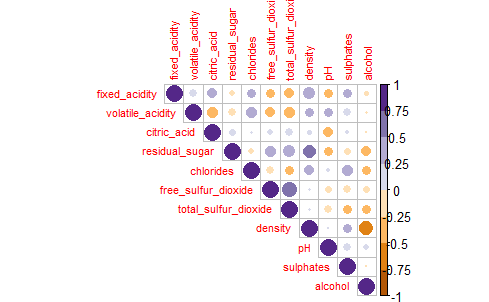

```r
cor_ <- cor(wine_num)
corrplot(cor_, type="upper", tl.cex = 0.7,col=brewer.pal(n=8, name="PuOr"))
```

### Histogramas.

```r
names <- colnames(wine)
```

Obtenemos el nombre de las columnas.

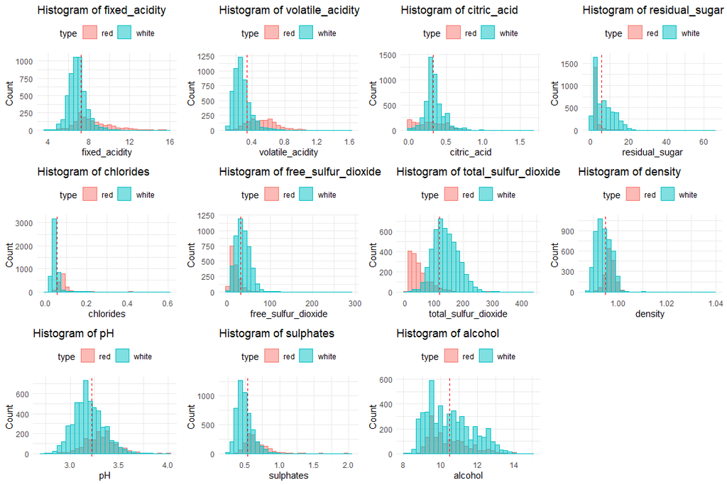

```r
h1 <- wine %>%
  ggplot(aes_string(x = names[1], fill = "type", color = "type")) +
  geom_histogram(position = "identity", alpha = 0.5, bins = 30) +
  geom_vline(aes(xintercept = mean(.data[[names[1]]], na.rm = TRUE)), color = "red", linetype = "dashed") +
  labs(title = paste("Histogram of", names[1]),
       x = names[1],
       y = "Count") +
  theme_minimal() +
  theme(legend.position = "top")

h2 <- wine %>%
  ggplot(aes_string(x = names[2], fill = "type", color = "type")) +
  geom_histogram(position = "identity", alpha = 0.5, bins = 30) +
  geom_vline(aes(xintercept = mean(.data[[names[2]]], na.rm = TRUE)), color = "red", linetype = "dashed") +
  labs(title = paste("Histogram of", names[2]),
       x = names[2],
       y = "Count") +
  theme_minimal() +
  theme(legend.position = "top")

h3 <- wine %>%
  ggplot(aes_string(x = names[3], fill = "type", color = "type")) +
  geom_histogram(position = "identity", alpha = 0.5, bins = 30) +
  geom_vline(aes(xintercept = mean(.data[[names[3]]], na.rm = TRUE)), color = "red", linetype = "dashed") +
  labs(title = paste("Histogram of", names[3]),
       x = names[3],
       y = "Count") +
  theme_minimal() +
  theme(legend.position = "top")

h4 <- wine %>%
  ggplot(aes_string(x = names[4], fill = "type", color = "type")) +
  geom_histogram(position = "identity", alpha = 0.5, bins = 30) +
  geom_vline(aes(xintercept = mean(.data[[names[4]]], na.rm = TRUE)), color = "red", linetype = "dashed") +
  labs(title = paste("Histogram of", names[4]),
       x = names[4],
       y = "Count") +
  theme_minimal() +
  theme(legend.position = "top")

h5 <- wine %>%
  ggplot(aes_string(x = names[5], fill = "type", color = "type")) +
  geom_histogram(position = "identity", alpha = 0.5, bins = 30) +
  geom_vline(aes(xintercept = mean(.data[[names[5]]], na.rm = TRUE)), color = "red", linetype = "dashed") +
  labs(title = paste("Histogram of", names[5]),
       x = names[5],
       y = "Count") +
  theme_minimal() +
  theme(legend.position = "top")

h6 <- wine %>%
  ggplot(aes_string(x = names[6], fill = "type", color = "type")) +
  geom_histogram(position = "identity", alpha = 0.5, bins = 30) +
  geom_vline(aes(xintercept = mean(.data[[names[6]]], na.rm = TRUE)), color = "red", linetype = "dashed") +
  labs(title = paste("Histogram of", names[6]),
       x = names[6],
       y = "Count") +
  theme_minimal() +
  theme(legend.position = "top")

h7 <- wine %>%
  ggplot(aes_string(x = names[7], fill = "type", color = "type")) +
  geom_histogram(position = "identity", alpha = 0.5, bins = 30) +
  geom_vline(aes(xintercept = mean(.data[[names[7]]], na.rm = TRUE)), color = "red", linetype = "dashed") +
  labs(title = paste("Histogram of", names[7]),
       x = names[7],
       y = "Count") +
  theme_minimal() +
  theme(legend.position = "top")

h8 <- wine %>%
  ggplot(aes_string(x = names[8], fill = "type", color = "type")) +
  geom_histogram(position = "identity", alpha = 0.5, bins = 30) +
  geom_vline(aes(xintercept = mean(.data[[names[8]]], na.rm = TRUE)), color = "red", linetype = "dashed") +
  labs(title = paste("Histogram of", names[8]),
       x = names[8],
       y = "Count") +
  theme_minimal() +
  theme(legend.position = "top")

h9 <- wine %>%
  ggplot(aes_string(x = names[9], fill = "type", color = "type")) +
  geom_histogram(position = "identity", alpha = 0.5, bins = 30) +
  geom_vline(aes(xintercept = mean(.data[[names[9]]], na.rm = TRUE)), color = "red", linetype = "dashed") +
  labs(title = paste("Histogram of", names[9]),
       x = names[9],
       y = "Count") +
  theme_minimal() +
  theme(legend.position = "top")

h10 <- wine %>%
  ggplot(aes_string(x = names[10], fill = "type", color = "type")) +
  geom_histogram(position = "identity", alpha = 0.5, bins = 30) +
  geom_vline(aes(xintercept = mean(.data[[names[10]]], na.rm = TRUE)), color = "red", linetype = "dashed") +
  labs(title = paste("Histogram of", names[10]),
       x = names[10],
       y = "Count") +
  theme_minimal() +
  theme(legend.position = "top")

h11 <- wine %>%
  ggplot(aes_string(x = names[11], fill = "type", color = "type")) +
  geom_histogram(position = "identity", alpha = 0.5, bins = 30) +
  geom_vline(aes(xintercept = mean(.data[[names[11]]], na.rm = TRUE)), color = "red", linetype = "dashed") +
  labs(title = paste("Histogram of", names[11]),
       x = names[11],
       y = "Count") +
  theme_minimal() +
  theme(legend.position = "top")

ggarrange(h1, h2, h3, h4, h5, h6, h7, h8, h9, h10, h11, ncol = 4, nrow = 3)
```

## Boxplots.

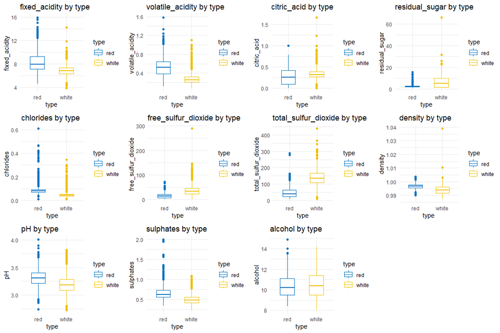

```r
b1 <- wine %>%
  ggboxplot(x = "type", y = names[1],
            color = "type", palette = "jco",
            width = 0.5) +
  labs(title = paste(names[1], "by type")) +
  theme_minimal()

b2 <- wine %>%
  ggboxplot(x = "type", y = names[2],
            color = "type", palette = "jco",
            width = 0.5) +
  labs(title = paste(names[2], "by type")) +
  theme_minimal()

b3 <- wine %>%
  ggboxplot(x = "type", y = names[3],
            color = "type", palette = "jco",
            width = 0.5) +
  labs(title = paste(names[3], "by type")) +
  theme_minimal()

b4 <- wine %>%
  ggboxplot(x = "type", y = names[4],
            color = "type", palette = "jco",
            width = 0.5) +
  labs(title = paste(names[4], "by type")) +
  theme_minimal()

b5 <- wine %>%
  ggboxplot(x = "type", y = names[5],
            color = "type", palette = "jco",
            width = 0.5) +
  labs(title = paste(names[5], "by type")) +
  theme_minimal()

b6 <- wine %>%
  ggboxplot(x = "type", y = names[6],
            color = "type", palette = "jco",
            width = 0.5) +
  labs(title = paste(names[6], "by type")) +
  theme_minimal()

b7 <- wine %>%
  ggboxplot(x = "type", y = names[7],
            color = "type", palette = "jco",
            width = 0.5) +
  labs(title = paste(names[7], "by type")) +
  theme_minimal()

b8 <- wine %>%
  ggboxplot(x = "type", y = names[8],
            color = "type", palette = "jco",
            width = 0.5) +
  labs(title = paste(names[8], "by type")) +
  theme_minimal()

b9 <- wine %>%
  ggboxplot(x = "type", y = names[9],
            color = "type", palette = "jco",
            width = 0.5) +
  labs(title = paste(names[9], "by type")) +
  theme_minimal()

b10 <- wine %>%
  ggboxplot(x = "type", y = names[10],
            color = "type", palette = "jco",
            width = 0.5) +
  labs(title = paste(names[10], "by type")) +
  theme_minimal()

b11 <- wine %>%
  ggboxplot(x = "type", y = names[11],
            color = "type", palette = "jco",
            width = 0.5) +
  labs(title = paste(names[11], "by type")) +
  theme_minimal()

ggarrange(b1, b2, b3, b4, b5, b6, b7, b8, b9, b10, b11, ncol = 4, nrow = 3)
```

## Análisis de Normalidad.

### Univariados.

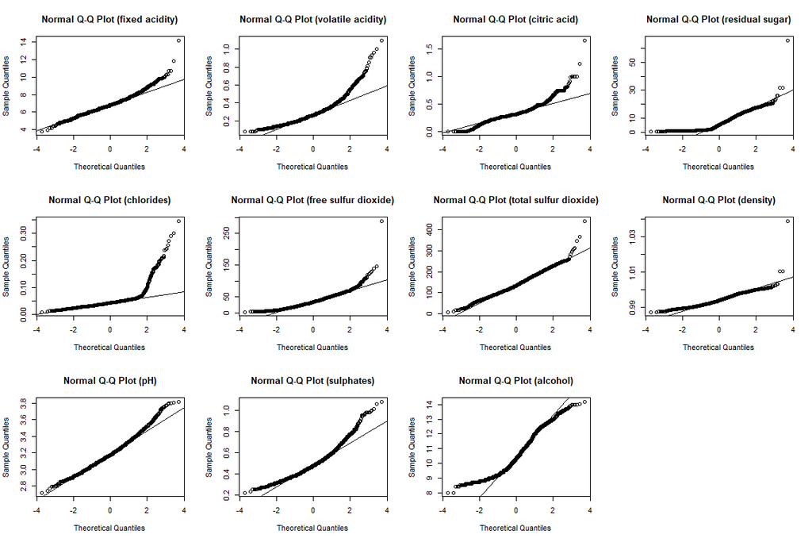

```r
white_whine_univariateNormal <- MVN::mvn(data = white_wine_num,
         univariatePlot = "qqplot")
```

```r
white_whine_univariateNormal$univariateNormality
```

|  | Test | Variable | Statistic | p value | Normality |
| --- | --- | --- | --- | --- | --- |
| 1 | Anderson-Darling | fixed acidity | 21.8347 | <0.001 | NO |
| 2 | Anderson-Darling | volatile acidity | 83.8841 | <0.001 | NO |
| 3 | Anderson-Darling | citric acid | 89.9292 | <0.001 | NO |
| 4 | Anderson-Darling | residual sugar | 160.9273 | <0.001 | NO |
| 5 | Anderson-Darling | chlorides | 406.7420 | <0.001 | NO |
| 6 | Anderson-Darling | free sulfur dioxide | 21.9327 | <0.001 | NO |
| 7 | Anderson-Darling | total sulfur dioxide | 11.9390 | <0.001 | NO |
| 8 | Anderson-Darling | density | 22.6354 | <0.001 | NO |
| 9 | Anderson-Darling | pH | 11.9717 | <0.001 | NO |
| 10 | Anderson-Darling | sulphates | 50.2427 | <0.001 | NO |

[output cut: 1 more lines]

Primero realizamos las pruebas para el vino blanco.

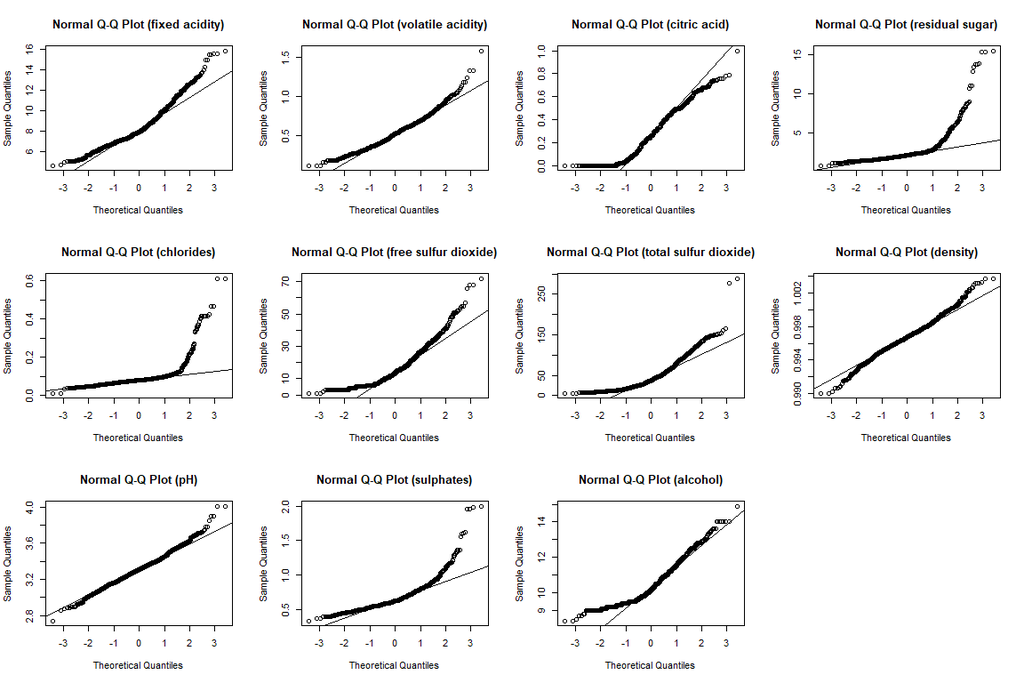

```r
red_whine_univariateNormal <- MVN::mvn(data = red_wine_num,
         univariatePlot = "qqplot")
```

```r
red_whine_univariateNormal$univariateNormality
```

|  | Test | Variable | Statistic | p value | Normality |
| --- | --- | --- | --- | --- | --- |
| 1 | Anderson-Darling | fixed acidity | 28.1430 | <0.001 | NO |
| 2 | Anderson-Darling | volatile acidity | 5.6831 | <0.001 | NO |
| 3 | Anderson-Darling | citric acid | 17.5421 | <0.001 | NO |
| 4 | Anderson-Darling | residual sugar | 188.0644 | <0.001 | NO |
| 5 | Anderson-Darling | chlorides | 210.4492 | <0.001 | NO |
| 6 | Anderson-Darling | free sulfur dioxide | 38.6099 | <0.001 | NO |
| 7 | Anderson-Darling | total sulfur dioxide | 52.4887 | <0.001 | NO |
| 8 | Anderson-Darling | density | 3.8676 | <0.001 | NO |
| 9 | Anderson-Darling | pH | 1.8641 | 1e-04 | NO |
| 10 | Anderson-Darling | sulphates | 46.9322 | <0.001 | NO |

[output cut: 1 more lines]

Y ahora para el vino tinto.

### Multivariados

```r
MVN::mvn(data = white_wine_num,
         mvnTest = 'mardia')$multivariateNormality
```

| Test | Statistic | p value | Result |
| --- | --- | --- | --- |
| Mardia Skewness | 235569.169372725 | 0 | NO |
| Mardia Kurtosis | 1461.69831443977 | 0 | NO |
| MVN | NA | NA | NO |

```r
mvn(data = white_wine_num,
    mvnTest = 'hz')$multivariateNormality
```

| Test | HZ | p value | MVN |
| --- | --- | --- | --- |
| Henze-Zirkler | 4.380657 | 0 | NO |

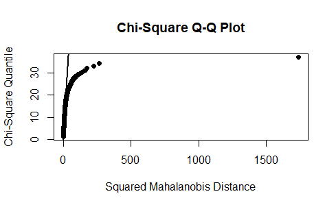

```r
MVN::mvn(white_wine_num,
         multivariatePlot = "qq")$multivariatePlot
```

Primero realizamos las pruebas para el vino blanco.

```r
MVN::mvn(data = red_wine_num,
         mvnTest = 'mardia')$multivariateNormality
```

| Test | Statistic | p value | Result |
| --- | --- | --- | --- |
| Mardia Skewness | 23791.1436242531 | 0 | NO |
| Mardia Kurtosis | 161.631091429313 | 0 | NO |
| MVN | NA | NA | NO |

```r
mvn(data = red_wine_num,
    mvnTest = 'hz')$multivariateNormality
```

| Test | HZ | p value | MVN |
| --- | --- | --- | --- |
| Henze-Zirkler | 4.575283 | 0 | NO |

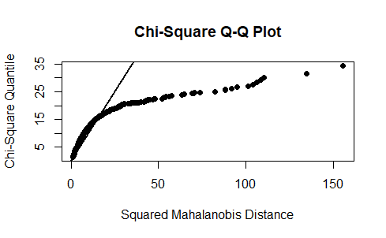

```r
MVN::mvn(red_wine_num,
         multivariatePlot = "qq")$multivariatePlot
```

Y ahora para el vino tinto.

### Transformación (Box-Cox).

```r
white_wine_boxcox <- as.data.frame(lapply(white_wine_num, function(x) {
  lambda <- BoxCox.lambda(x)
  BoxCox(x, lambda)
}))
```

```r
red_wine_boxcox <- as.data.frame(lapply(red_wine_num, function(x) {
  lambda <- BoxCox.lambda(x)
  BoxCox(x, lambda)
}))
```

Se aplica la transformación BoxCox en ambos datasets para mejorar la asimetría.

### Tratamiento de datos atípicos.

```r
outliers <- white_wine_boxcox %>%
  mahalanobis_distance() %>%
  filter(is.outlier == TRUE)

white_wine_num_t <- anti_join(white_wine_boxcox, outliers)
```

```r
outliers <- red_wine_boxcox %>%
  mahalanobis_distance() %>%
  filter(is.outlier == TRUE)

red_wine_num_t <- anti_join(red_wine_boxcox, outliers)
```

Y se eliminan los outliers de la transformación.

### Pruebas posteriores.

```r
MVN::mvn(data = white_wine_num_t,
         mvnTest = 'mardia')$multivariateNormality
```

| Test | Statistic | p value | Result |
| --- | --- | --- | --- |
| Mardia Skewness | 6466.34591793927 | 0 | NO |
| Mardia Kurtosis | 20.5555313264803 | 0 | NO |
| MVN | NA | NA | NO |

```r
mvn(data = white_wine_num_t,
    mvnTest = 'hz')$multivariateNormality
```

| Test | HZ | p value | MVN |
| --- | --- | --- | --- |
| Henze-Zirkler | 3.12227 | 0 | NO |

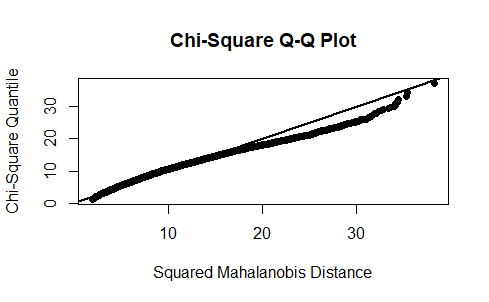

```r
MVN::mvn(white_wine_num_t,
         multivariatePlot = "qq")$multivariatePlot
```

Se aplican otra vez las pruebas para el vino blanco.

```r
MVN::mvn(data = red_wine_num_t,
         mvnTest = 'mardia')$multivariateNormality
```

| Test | Statistic | p value | Result |
| --- | --- | --- | --- |
| Mardia Skewness | 3749.97820915015 | 0 | NO |
| Mardia Kurtosis | 21.0813865078339 | 0 | NO |
| MVN | NA | NA | NO |

```r
mvn(data = red_wine_num_t,
    mvnTest = 'hz')$multivariateNormality
```

| Test | HZ | p value | MVN |
| --- | --- | --- | --- |
| Henze-Zirkler | 2.323498 | 0 | NO |

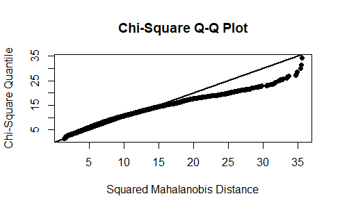

```r
MVN::mvn(red_wine_num_t,
         multivariatePlot = "qq")$multivariatePlot
```

Y después para el vino tinto.

## Análisis de Componentes Principales.

### Pruebas previas

#### Test de Bartlett

```r
Test.Bartlett <- cortest.bartlett(cor_, n=nrow(wine_num))
Test.Bartlett$p.value
```

```
[1] 0
```

Se realiza el test de Bartlett para ver si la correlación es significativa.

#### KMO

```r
KMO(wine_num)
```

```
Kaiser-Meyer-Olkin factor adequacy
Call: KMO(r = wine_num)
Overall MSA =  0.41
MSA for each item =
       fixed_acidity     volatile_acidity          citric_acid
                0.28                 0.61                 0.62
      residual_sugar            chlorides  free_sulfur_dioxide
                0.29                 0.73                 0.75
total_sulfur_dioxide              density                   pH
                0.72                 0.30                 0.21
           sulphates              alcohol
                0.56                 0.27
```

También el KMO para ver que tan viable es hacer un PCA.

### PCA

```r
componentestotal <- prcomp(wine_num, center=TRUE, scale.=TRUE)
```

se usa el paquete prcomp para realizar el PCA

### Elección del número de componentes

#### Elbow.

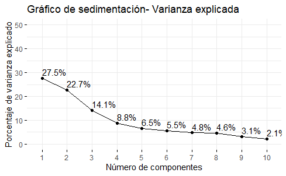

```r
fviz_eig(componentestotal, geom="line", ylim=c(0,50),
         main = "Gráfico de sedimentación- Varianza explicada",
         addlabels = TRUE, xlab = "Número de componentes",
         ylab="Porcentaje de varianza explicado")
```

Se ve que el gráfico de Elbow sugiere 5 componentes.

#### Pareto.

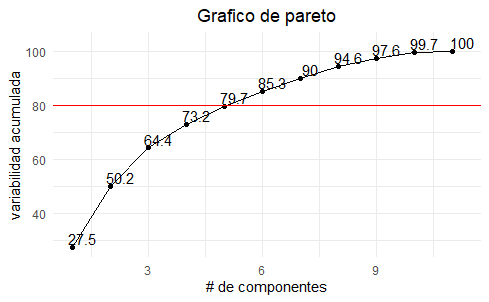

```r
lambdas <- as.data.frame(summary(componentestotal)[1])^2

tabla <- tibble(k = c(1:11), var_acum = unlist(cumsum(lambdas/11*100)))

tabla %>% ggplot(aes(x= k, y = var_acum))+
  geom_line() +
  geom_point() +
  geom_hline(yintercept = 80, color ="red") +
  geom_text(aes(label = after_stat(round(y,1))),
            nudge_x = 0.25, nudge_y = 3.25)+
  ggtitle("Grafico de pareto")+
  xlab("# de componentes")+
  ylab("variabilidad acumulada")+
  theme_minimal()+
  theme(plot.title = element_text(hjust = 0.5))
```

El gráfico de Pareto también aproximadamente.

#### Valores Propios.

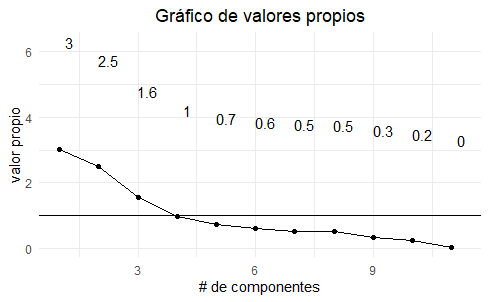

```r
auto_R <- eigen(cor_)
tabla <- tibble(k = c(1:11), lambda_i = auto_R$values)

tabla %>% ggplot(aes(x= k, y = lambda_i))+
  geom_line() +
  geom_point() +
  geom_hline(yintercept = 1) +
  geom_text(aes(label = after_stat(round(y,1))),
            nudge_x = 0.25, nudge_y = 3.25)+
  ggtitle("Gráfico de valores propios")+
  xlab("# de componentes")+
  ylab("valor propio")+
  theme_minimal()+
  theme(plot.title = element_text(hjust = 0.5))
```

Se eligieron 5 componentes dado que 2 de los 3 gráficos sugieren ese número.

### Cargas Factoriales.

```r
cargas <- as.data.frame(componentestotal$rotation)
cargas
```

|  | PC1 | PC2 | PC3 | PC4 | PC5 | PC6 | PC7 | PC8 | PC9 | PC10 | PC11 |
| --- | --- | --- | --- | --- | --- | --- | --- | --- | --- | --- | --- |
| fixed_acidity | -0.23879890 | -0.33635454 | -0.43430130 | 0.16434621 | -0.1474804 | -0.20455371 | -0.28307944 | 0.401235645 | -0.3440567 | 0.281267685 | 0.3346792663 |
| volatile_acidity | -0.38075750 | -0.11754972 | 0.30725942 | 0.21278489 | 0.1514560 | -0.49214307 | -0.38915976 | -0.087435088 | 0.4969327 | -0.152176731 | 0.0847718098 |
| citric_acid | 0.15238844 | -0.18329940 | -0.59056967 | -0.26430031 | -0.1553487 | 0.22763380 | -0.38128504 | -0.293412336 | 0.4026887 | -0.234463340 | -0.0011089514 |
| residual_sugar | 0.34591993 | -0.32991418 | 0.16468843 | 0.16744301 | -0.3533619 | -0.23347775 | 0.21797554 | -0.524872935 | -0.1080032 | 0.001372773 | 0.4497650778 |
| chlorides | -0.29011259 | -0.31525799 | 0.01667910 | -0.24474386 | 0.6143911 | 0.16097639 | -0.04606816 | -0.471516850 | -0.2964437 | 0.196630217 | 0.0434375867 |
| free_sulfur_dioxide | 0.43091401 | -0.07193260 | 0.13422395 | -0.35727894 | 0.2235323 | -0.34005140 | -0.29936325 | 0.207807585 | -0.3666563 | -0.480243340 | -0.0002125351 |
| total_sulfur_dioxide | 0.48741806 | -0.08726628 | 0.10746230 | -0.20842014 | 0.1581336 | -0.15127722 | -0.13891032 | 0.128621319 | 0.3206955 | 0.713663486 | -0.0626848131 |
| density | -0.04493664 | -0.58403734 | 0.17560555 | 0.07272496 | -0.3065613 | 0.01874307 | -0.04675897 | 0.004831136 | -0.1128800 | 0.003908289 | -0.7151620723 |
| pH | -0.21868644 | 0.15586900 | 0.45532412 | -0.41455110 | -0.4533764 | 0.29657890 | -0.41890702 | -0.028643277 | -0.1278367 | 0.141310977 | 0.2063605036 |
| sulphates | -0.29413517 | -0.19171577 | -0.07004248 | -0.64053571 | -0.1365769 | -0.29692579 | 0.52534311 | 0.165818022 | 0.2077642 | -0.045959499 | 0.0772024671 |

[output cut: 1 more lines]

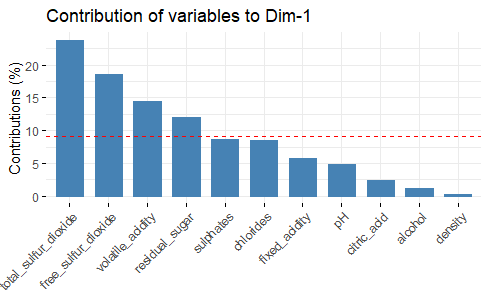

```r
fviz_contrib(componentestotal,choice="var", axes=1)
```

La variable con mayor carga factorial para la primera componente es total_sulfur_dioxide.

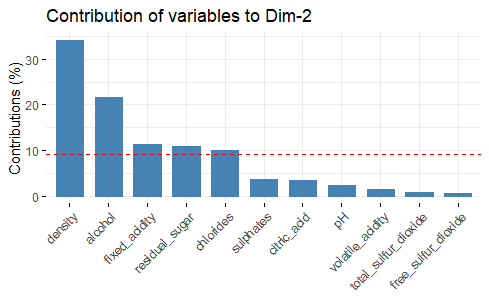

```r
fviz_contrib(componentestotal,choice="var", axes=2)
```

La variable con mayor carga factorial para la segunda componente es density

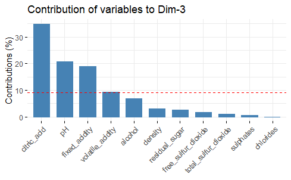

```r
fviz_contrib(componentestotal,choice="var", axes=3)
```

La variable con mayor carga factorial para la tercera componente es citric_acid.

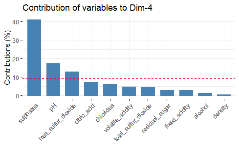

```r
fviz_contrib(componentestotal,choice="var", axes=4)
```

La variable con mayor carga factorial para la cuarta componente es sulphates.

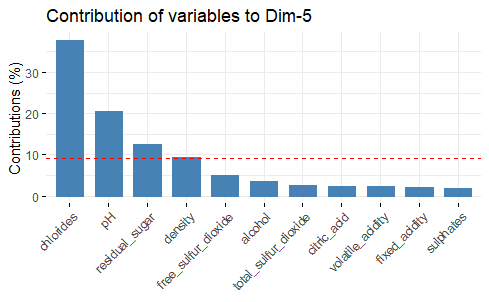

```r
fviz_contrib(componentestotal,choice="var", axes=5)
```

La variable con mayor carga factorial para la quinta componente es chlorides.

### Rotación Ortogonal.

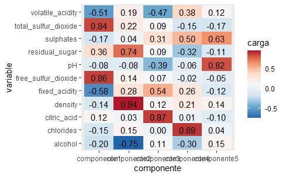

```r
componentes <- principal(wine_num, nfactors=5, rotate="varimax")

componente1 <- componentes$loadings[,1]
componente2 <- componentes$loadings[,2]
componente3 <- componentes$loadings[,3]
componente4 <- componentes$loadings[,4]
componente5 <- componentes$loadings[,5]

cargasdfr <- as.data.frame(cbind(componente1, componente2, componente3, componente4, componente5))
cargasdfr$medicion <- rownames(cargasdfr)
cargasheatr <- reshape2::melt(cargasdfr)

colnames(cargasheatr) <- c("variable","componente","carga")
cargasheatr %>%
  ggplot(aes(x=componente,y=variable,fill=carga,
             label=sprintf("%0.2f", round(carga, digits=2))))+
  geom_tile()+
  scale_fill_distiller(palette="RdBu")+
  geom_text()
```

Acá podemos observar las variables con mayor carga en cada componente, e identificar cual es el factor latente de cada una.

```r
componentes$communality
```

```
       fixed_acidity     volatile_acidity          citric_acid
           0.7903418            0.6811080            0.7821311
      residual_sugar            chlorides  free_sulfur_dioxide
           0.7933024            0.8331696            0.7634089
total_sulfur_dioxide              density                   pH
           0.8169507            0.9775418            0.8429119
           sulphates              alcohol
           0.7730583            0.7165441
```

Podemos ver que todas las variables están bien representadas.

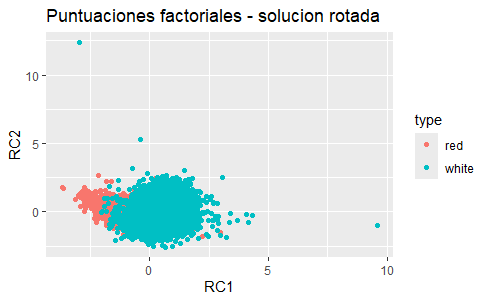

```r
#Graficar puntos sobre planos factoriales
PCA_wine <- componentes$scores
wine_with_PCA <- cbind(wine,PCA_wine)
wine_with_PCA <- wine_with_PCA %>%
  mutate(type = as.factor(type))

wine_with_PCA %>%
  ggplot(aes(x=RC1,y=RC2,color=type))+
  geom_point()+
  ggtitle("Puntuaciones factoriales - solucion rotada")
```

No se ve una muy buena separación.

## Regresión Logística.

```r
set.seed(0214)
wine$type <- ifelse(wine$type == "red", 1, 0)
wine_num_est <- wine_num %>% scale()
wine_num_logreg <- as.data.frame(cbind(wine_num_est, type = wine$type))
```

Preparamos el dataset estandarizando y añadiendo la columna type.

### Primer modelo y revisión de supuestos

```r
#Creación del modelo
reg_log <- glm(type~., data = wine_num_logreg, family = binomial)

#VIF
car::vif(reg_log)
```

```
       fixed_acidity     volatile_acidity          citric_acid
            3.745162             1.586839             1.625308
      residual_sugar            chlorides  free_sulfur_dioxide
            2.343361             1.447304             2.097711
total_sulfur_dioxide              density                   pH
            2.021329            10.240818             2.700131
           sulphates              alcohol
            1.357355             5.089580
```

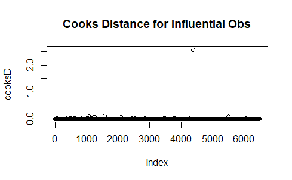

```r
#Cooks distance
cooksD <- cooks.distance(reg_log)

# Plot Cook's Distance with a horizontal line at 1 to see which observations
#exceed this thresdhold
n <- nrow(wine_num_logreg)
plot(cooksD, main = "Cooks Distance for Influential Obs")
abline(h = 1, lty = 2, col = "steelblue") # add cutoff line
```

```r
#identify influential points
influential_obs <- as.numeric(names(cooksD)[(cooksD > 1)])

#define new data frame with influential points and a column removed
wine_num_logreg <- wine_num_logreg[-influential_obs, ]
wine_num_logreg <- wine_num_logreg %>% select(-density)
```

Vemos que hay una entrada del dataset que debe ser eliminado porque puede afectar negativamente el modelo, además se eliminará density porque tiene un VIF mayor a 10

### Partición de la base de datos.

```r
trainIndex <- wine_num_logreg$type %>%
createDataPartition(p = 0.8, list = FALSE)

train <- wine_num_logreg[trainIndex,]
test <- wine_num_logreg[-trainIndex,]
```

### Creación del modelo

```r
reg_log <- glm(type~., data = train, family = binomial)
```

### Coeficientes

```r
coeficientes <- reg_log$coefficients
coeficientes
```

```
         (Intercept)        fixed_acidity     volatile_acidity
          -4.1859100            1.8253259            1.8904148
         citric_acid       residual_sugar            chlorides
          -0.1540146           -0.5226947            1.2458997
 free_sulfur_dioxide total_sulfur_dioxide                   pH
           0.9946641           -3.7783293            1.5113484
           sulphates              alcohol
           1.3090202           -0.4675617
```

### Odd_ratios

```r
cambio_odd <- exp(coeficientes)
cambio_odd
```

```
         (Intercept)        fixed_acidity     volatile_acidity
          0.01520836           6.20481657           6.62211526
         citric_acid       residual_sugar            chlorides
          0.85725949           0.59292064           3.47606065
 free_sulfur_dioxide total_sulfur_dioxide                   pH
          2.70381585           0.02286085           4.53283869
           sulphates              alcohol
          3.70254410           0.62652808
```

### Odd_base de la clase positiva

```r
base <- table(wine$type)
prop.table(base)
```

```
        0         1
0.7538864 0.2461136
```

```r
odd_base <- prop.table(base)[2]/prop.table(base)[1]
odd_base
```

```
        1
0.3264598
```

### Probabilidad final

```r
odd_final <- odd_base*cambio_odd

prob_fin_1p <- odd_final/(1+odd_final)
prob_fin_1p
```

```
         (Intercept)        fixed_acidity     volatile_acidity
         0.004940389          0.669489562          0.683729891
         citric_acid       residual_sugar            chlorides
         0.218664996          0.162173643          0.531570726
 free_sulfur_dioxide total_sulfur_dioxide                   pH
         0.468844299          0.007407863          0.596739969
           sulphates              alcohol
         0.547251490          0.169804956
```

### Predicciones

```r
probas <- reg_log %>%
  predict(test, type = "response")

pred_class <- if_else(probas > 0.5, 1, 0)
```

### APER

```r
1 - mean(pred_class == test$type)
```

```
[1] 0.01231717
```

### Matriz de confusión

```r
table(pred_class, test$type)
```

```
pred_class   0   1
         0 969   9
         1   7 314
```

### Cook’s distance

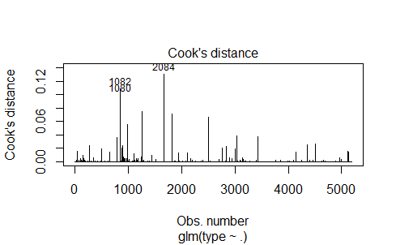

```r
plot(reg_log, which = 4, id.n = 3)
```

### VIF

```r
car::vif(reg_log)
```

```
       fixed_acidity     volatile_acidity          citric_acid
            1.770278             1.677962             1.736255
      residual_sugar            chlorides  free_sulfur_dioxide
            1.135566             1.437715             1.821000
total_sulfur_dioxide                   pH            sulphates
            2.491303             1.692084             1.289073
             alcohol
            1.486675
```

El modelo no posee problemas significativos en los supuestos, además de tener un buen APER.

### K-fold cross validation

```r
k <- 10
folds <- sample(1:k, nrow(wine_num_logreg), replace = TRUE)

# Crear un vector para almacenar precisión en cada fold
accuracy <- numeric(k)

for (i in 1:k) {
  # Dividir datos en entrenamiento y prueba
  train_data <- wine_num_logreg[folds != i, ]
  test_data <- wine_num_logreg[folds == i, ]

  # Ajustar modelo
  modelo <- glm(type ~ ., data = train_data, family = "binomial")

  # Predecir en conjunto de prueba
  pred <- predict(modelo, newdata = test_data, type = "response")
  pred_class <- ifelse(pred > 0.5, 1, 0)

  # Calcular precisión
  accuracy[i] <- mean(pred_class == test_data$type)
}

# Promedio de precisión (Accuracy)
mean_APER <- 1 - mean(accuracy)
print(paste("APER promedio:", round(mean_APER, 4)))
```

```
[1] "APER promedio: 0.0113"
```

## Clustering

### Revisión de variabilidad

```r
CV <- function(var){(sd(var)/mean(var))*100}
apply(wine_num,2, CV)
```

```
       fixed_acidity     volatile_acidity          citric_acid
          17.9678252           48.4701072           45.6066279
      residual_sugar            chlorides  free_sulfur_dioxide
          87.4076436           62.5221969           58.1464834
total_sulfur_dioxide              density                   pH
          48.8332648            0.3014661            4.9957173
           sulphates              alcohol
          28.0095537           11.3680365
```

no se ve muy buen porcentaje de variación, únicamente en residual_sugar.

### Elección de número de clusters

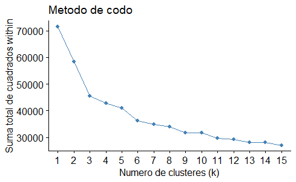

```r
fviz_nbclust(wine_num_est, kmeans, method = "wss", k.max = 15) +
  labs(title = "Metodo de codo")+
  xlab("Numero de clusteres (k)")+
  ylab("Suma total de cuadrados within")
```

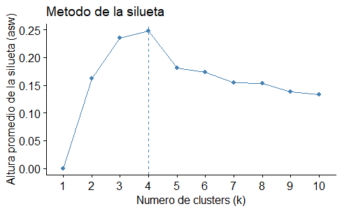

```r
fviz_nbclust(wine_num_est, kmeans, method = "silhouette")+
  labs(title = "Metodo de la silueta")+
  xlab("Numero de clusters (k)")+
  ylab("Altura promedio de la silueta (asw)")
```

Esta medida indica que 4 clusters sería lo óptimo.

```r
gap_stat <- clusGap(wine_num_est, FUN = kmeans, K.max = 6, B = 100)
```

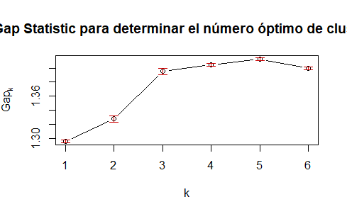

```r
plot(gap_stat, main = "Gap Statistic para determinar el número óptimo de clusters")
```

```r
print(gap_stat)
```

```
Clustering Gap statistic ["clusGap"] from call:
clusGap(x = wine_num_est, FUNcluster = kmeans, K.max = 6, B = 100)
B=100 simulated reference sets, k = 1..6; spaceH0="scaledPCA"
 --> Number of clusters (method 'firstSEmax', SE.factor=1): 5
         logW    E.logW      gap      SE.sim
[1,] 8.873237 10.168955 1.295717 0.001990292
[2,] 8.759949 10.087401 1.327452 0.004435334
[3,] 8.635378 10.030715 1.395337 0.004406734
[4,] 8.584878  9.989433 1.404555 0.002299512
[5,] 8.546189  9.959049 1.412860 0.002302629
[6,] 8.531727  9.931612 1.399885 0.001910404
```

### K-means

```r
wine_cluster <- kmeans(wine_num_est,
                        centers=4,nstart=10,iter.max=20)
```

```r
wine_cluster$size
```

```
[1] 1873  687 1007 2930
```

### Análisis descriptivo

Primero se mirarán los centroides de cada cluster.

```r
centrosg <- as.data.frame(wine_cluster$centers)
centrosg$grupo <- as.factor(rownames(centrosg))
centrosheat <- reshape2::melt(centrosg)
```

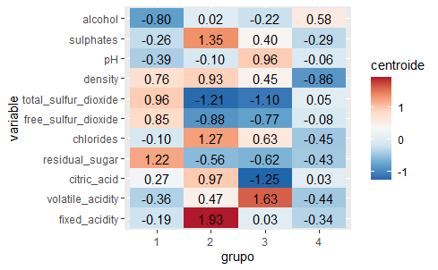

```r
colnames(centrosheat) <- c("grupo","variable","centroide")

centrosheat %>%
  ggplot(aes(x=grupo,y=variable,fill=centroide, label=sprintf("%0.2f", round(centroide, digits=2))))+
  geom_tile()+
  scale_fill_distiller(palette="RdBu")+
  geom_text()
```

Ahora se procede a revisar los boxplots.

```r
wine_num$cluster <- wine_cluster$cluster
```

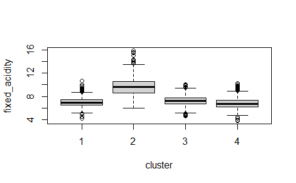

```r
boxplot(fixed_acidity~cluster, data=wine_num)
```

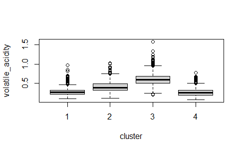

```r
boxplot(volatile_acidity~cluster, data=wine_num)
```

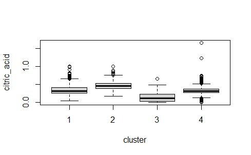

```r
boxplot(citric_acid~cluster, data=wine_num)
```

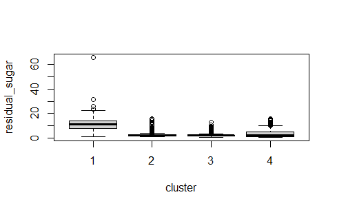

```r
boxplot(residual_sugar~cluster, data=wine_num)
```

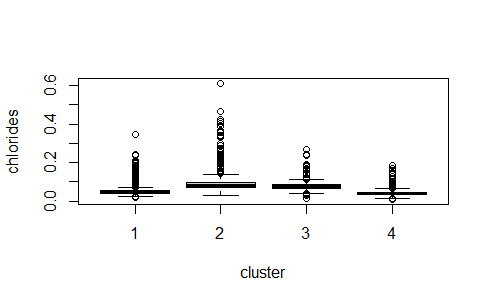

```r
boxplot(chlorides~cluster, data=wine_num)
```

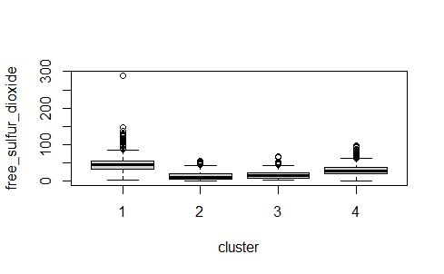

```r
boxplot(free_sulfur_dioxide~cluster, data=wine_num)
```

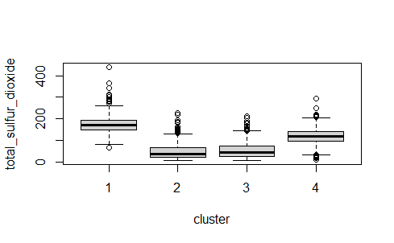

```r
boxplot(total_sulfur_dioxide~cluster, data=wine_num)
```

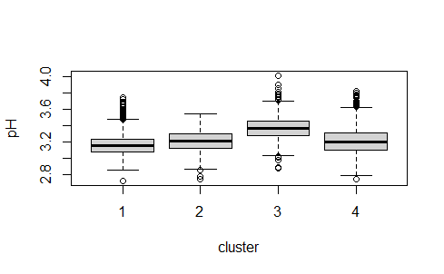

```r
boxplot(pH~cluster, data=wine_num)
```

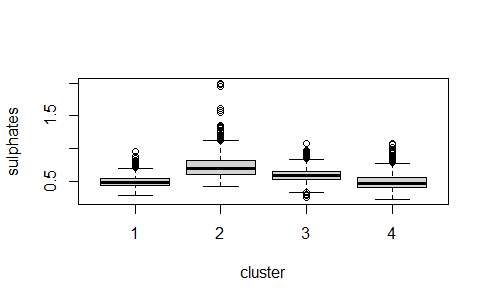

```r
boxplot(sulphates~cluster, data=wine_num)
```

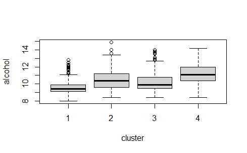

```r
boxplot(alcohol~cluster, data=wine_num)
```

[figure not shown]

```r
boxplot(alcohol~cluster, data=wine_num)
```

```r
kclusters <- clusterboot(wine_num_est, B=100,
                         clustermethod=kmeansCBI, k=4, seed=5)
```

```r
kclusters$bootmean
```

```
[1] 0.5643055 0.7542696 0.8806795 0.6822231
```

vemos que el primer grupo es malo según el método, mientras que los otros son buenos.

## Regresión Logística sobre los clusters como variable predictora.

```r
clusters <- as.data.frame(wine_cluster$cluster)
clusters <- clusters[-influential_obs, ]

wine_num_logreg$cluster <- clusters
```

### Partición de la base de datos.

```r
trainIndex <- wine_num_logreg$type %>%
  createDataPartition(p = 0.8, list = FALSE)

train <- wine_num_logreg[trainIndex,]
test <- wine_num_logreg[-trainIndex,]
```

### Creación del modelo

```r
reg_log <- glm(type~., data = train, family = binomial)
```

### Coeficientes

```r
coeficientes <- reg_log$coefficients
coeficientes
```

```
         (Intercept)        fixed_acidity     volatile_acidity
          -3.5254332            2.0285415            1.9120685
         citric_acid       residual_sugar            chlorides
          -0.1725681           -0.6139562            1.3033248
 free_sulfur_dioxide total_sulfur_dioxide                   pH
           1.1129206           -3.8411428            1.5856950
           sulphates              alcohol              cluster
           1.2641931           -0.2893095           -0.2484405
```

### Odd_ratios

```r
cambio_odd <- exp(coeficientes)
cambio_odd
```

```
         (Intercept)        fixed_acidity     volatile_acidity
          0.02943905           7.60298947           6.76707227
         citric_acid       residual_sugar            chlorides
          0.84150101           0.54120551           3.68151674
 free_sulfur_dioxide total_sulfur_dioxide                   pH
          3.04323347           0.02146905           4.88268360
           sulphates              alcohol              cluster
          3.54023498           0.74878044           0.78001624
```

### Odd_base de la clase positiva

```r
base <- table(wine$type)
prop.table(base)
```

```
        0         1
0.7538864 0.2461136
```

```r
odd_base <- prop.table(base)[2]/prop.table(base)[1]
odd_base
```

```
        1
0.3264598
```

### Probabilidad final

```r
odd_final <- odd_base*cambio_odd

prob_fin_1p <- odd_final/(1+odd_final)
prob_fin_1p
```

```
         (Intercept)        fixed_acidity     volatile_acidity
         0.009519181          0.712814526          0.688393621
         citric_acid       residual_sugar            chlorides
         0.215511678          0.150152596          0.545839992
 free_sulfur_dioxide total_sulfur_dioxide                   pH
         0.498368022          0.006960001          0.614494961
           sulphates              alcohol              cluster
         0.536123099          0.196430027          0.202961114
```

### Predicciones

```r
probas <- reg_log %>%
  predict(test, type = "response")

pred_class <- if_else(probas > 0.5, 1, 0)
```

### APER

```r
1 - mean(pred_class == test$type)
```

```
[1] 0.01308699
```

### Matriz de confusión

```r
table(pred_class, test$type)
```

```
pred_class    0    1
         0 1000   10
         1    7  282
```

### Cook’s distance

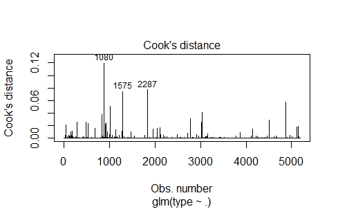

```r
plot(reg_log, which = 4, id.n = 3)
```

### VIF

```r
car::vif(reg_log)
```

```
       fixed_acidity     volatile_acidity          citric_acid
            1.973431             1.815913             1.830606
      residual_sugar            chlorides  free_sulfur_dioxide
            1.392447             1.703079             1.939732
total_sulfur_dioxide                   pH            sulphates
            2.615033             1.848729             1.360519
             alcohol              cluster
            1.765747             1.904788
```

Podemos ver que el APER es muy similar, además que el modelo cumple con los supuestos.

### K-fold cross validation

```r
k <- 10
folds <- sample(1:k, nrow(wine_num_logreg), replace = TRUE)

# Crear un vector para almacenar precisión en cada fold
accuracy <- numeric(k)

for (i in 1:k) {
  # Dividir datos en entrenamiento y prueba
  train_data <- wine_num_logreg[folds != i, ]
  test_data <- wine_num_logreg[folds == i, ]

  # Ajustar modelo
  modelo <- glm(type ~ ., data = train_data, family = "binomial")

  # Predecir en conjunto de prueba
  pred <- predict(modelo, newdata = test_data, type = "response")
  pred_class <- ifelse(pred > 0.5, 1, 0)

  # Calcular precisión
  accuracy[i] <- mean(pred_class == test_data$type)
}

# Promedio de precisión (Accuracy)
mean_APER <- 1 - mean(accuracy)
print(paste("APER promedio:", round(mean_APER, 4)))
```

```
[1] "APER promedio: 0.0114"
```

El APER es muy similar al anterior.